# Bug fix documentation

Matthew and Gloria

2018-07-10

This document will discuss the bugs experienced by users of the LDheatmap package, the code to replicate the bugs, and the implemented solutions. The aim is to provide a concise walk through of the process and to highlight any need for further changes.

```r
# To install bioconductor libraries
#source("https://bioconductor.org/biocLite.R")
#biocLite()
#biocLite("snpStats")
#biocLite("rtracklayer")

require(LDheatmap)
require(snpStats)
require(rtracklayer)
require(grid)
require(viridis)
# Other files that have modified code
if(!exists("LDTest", mode="function")) source("LDHeatmapTestFunctionMR.R")
if(!exists("LDheatmapMapNew.add", mode="function")) source("LDheatmapHelpers.R")
```

The following is the sample code provided in the Vignette, found here: https://cran.r-project.org/web/packages/LDheatmap/vignettes/addTracks.pdf

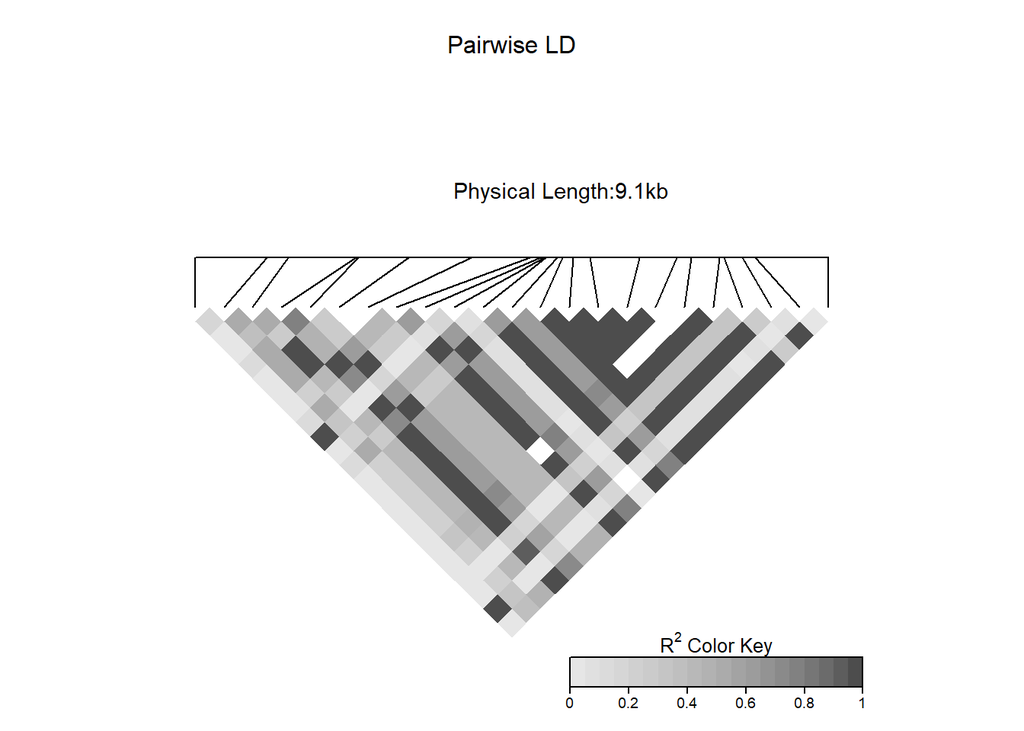

```r
data(GIMAP5.CEU)
load(system.file("extdata/addTracks.RData",package="LDheatmap"))

ll <-LDheatmap(GIMAP5.CEU$snp.data,GIMAP5.CEU$snp.support$Position,flip=TRUE)
# addGenes sometimes throws "Error: Bad Request" when called with the same parameters as addRecombRate, even though it grabs the requested values
# Just run grid.draw(llGenes$LDheatmapGrob) after to get the desired chart. Only necessary on my laptop for some reason

# Commented out to save run time
#llGenes <- LDheatmap.addGenes(ll, chr="chr7", genome="hg18")

#grid.newpage()
#grid.draw(llGenes$LDheatmapGrob)

# llGenesRecomb <- LDheatmap.addRecombRate(llGenes, chr="chr7", genome="hg18")
#
# grid.newpage()
# grid.draw(llGenesRecomb$LDheatmapGrob)
#
set.seed(1)
atests <- runif(nrow(GIMAP5.CEU$snp.support))
names(atests) <- rownames(GIMAP5.CEU$snp.support)
atests["rs6598"]<-1e-5
#
# llGenesRecombScatter <- LDheatmap.addScatterplot(llGenesRecomb,-log10(atests),
#                                                  ylab="-log10(p-values)")
#
# Adds Manhatten plot above our graph using qplot function in ggplot
require("ggplot2")
posn <- GIMAP5.CEU$snp.support$Position
manhattan2<-ggplotGrob(
  {
    qplot(posn,-log10(atests),xlab="", xlim=range(posn),asp=1/10)
    last_plot() + theme(axis.text.x=element_blank(),
                        axis.title.y = element_text(size = rel(0.75)))
  }
)
llQplot<-LDheatmap.addGrob(ll,manhattan2,height=.7)
```

[figure not shown]

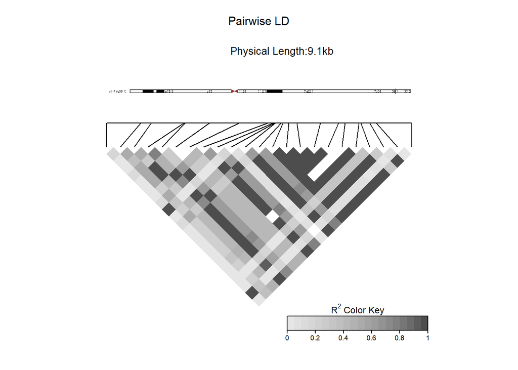

```r
llImage<-LDheatmap.addGrob(ll,rasterGrob(GIMAP5ideo))
```

As LDheatmap has been used in many different papers and works over the years, users have experienced corner case behaviour beyond what is laid out in the original vignettes. The general core of the package is functional and handles most necessary functions adequately. We were tasked with evaluating whether the package needed an overhaul or if bug fixing would be sufficient.

Exploration of the bugs found that one component of the package often triggered corner case behaviour. The flipping of the heatmap, done by rotating a viewport, caused a collection of bugs. Upon review, the bugs appear to have been oversights or small missteps in the code. What follows is a discussion of each bug, the code that generates the undesired output (if applicable), and the suggested fix along with an example of how it solves the problem.

Bug Report 1: When the heatmap is flipped, symbols used to mark given SNPs in the genome are removed. This behaviour does not occur in the non-flipped version.

Example of the bug:

```r
# Bug report: "Symbols" are gone when LDheatmap is generated with flip = TRUE
# Fix: LDheatmapMap.add() had a code section only if(flip) that set symbols <- NULL.
    # Resolved by using same assignment as was used in the non-flipped case
require('LDheatmap')

 # taken from examples LDheatmap\demo\LDheatmap.R, works correctly
data(CEUData)
MyHeatmap <- LDheatmap(CEUSNP, genetic.distances = CEUDist,
                          color = grey.colors(20))
```

```r
LDheatmap(MyHeatmap, SNP.name = c("rs2283092", "rs6979287"))
```

```r
childNames(grid.get("geneMap"))
```

```
## [1] "diagonal" "segments" "title"    "symbols"  "SNPnames"
```

```r
 #BUG: With flip=TRUE it does not work anymore
  MyHeatmapF <- LDheatmap(CEUSNP, genetic.distances = CEUDist,
                            color = grey.colors(20), flip=TRUE)
```

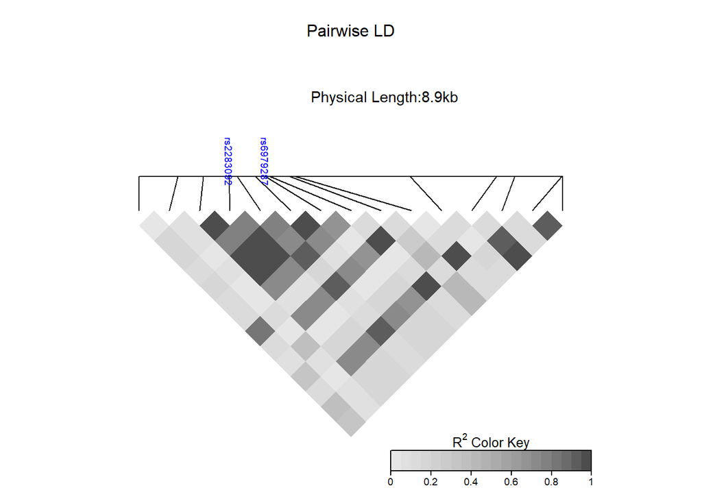

```r
  LDheatmap(MyHeatmapF, SNP.name = c("rs2283092", "rs6979287"))
```

```r
  childNames(grid.get("geneMap"))
```

```
## [1] "diagonal" "segments" "title"    "SNPnames"
```

```r
  MyHeatmapTest <- LDheatmap(CEUSNP, genetic.distances = CEUDist,
                          color = grey.colors(20), flip=FALSE)
```

```r
  LDheatmap(MyHeatmapTest, SNP.name = c("rs2283092", "rs6979287"))
```

```r
  childNames(grid.get("geneMap"))
```

```
## [1] "diagonal" "segments" "title"    "symbols"  "SNPnames"
```

The result of the code above shows the flipped graph, when specific SNP names are given, fails to output the symbols requested. This is further noted as the childNames() call to the flipped graph’s genemap does not display ‘symbols’ as one of the children. Other uses of childNames() on non-flipped graphs return ‘symbols’ as a child of the genemap.

The bug-producing code can be found in the LDheatmapMap.add() function from this package. Below is the segment that causes the undesired behaviour.

```r
## Labelling some SNPs
placeholder <- function(nsnps, add.map, genetic.distances,
                     geneMapLocation=0.15,
                     geneMapLabelX=NULL, geneMapLabelY=NULL,
                     distances="physical", vp=NULL,
                     SNP.name=NULL, ind=0, flip=FALSE){
  # # # # # #
  if (!is.null(SNP.name) && (any(ind!=0))){
    symbols <- pointsGrob(snp[ind], snp[ind], pch="*",
              gp=gpar(cex=1.25, bg="blue", col="blue"), name="symbols", vp=vp)
    SNPnames <- textGrob(paste(" ", SNP.name), just="left", rot=-45,
            regionx[ind], regiony[ind], gp=gpar(cex=0.6, col="blue"), name="SNPnames", vp=vp)
    if (flip) {
      lenght_SNP_name <- max(nchar(SNP.name))
      long_SNP_name <- paste(rep(8,lenght_SNP_name), collapse="")
      name_gap <- convertWidth(grobWidth(textGrob(long_SNP_name)), "npc",valueOnly=TRUE)/sqrt(2)
      diagonal<-linesGrob(seq.x, seq.y, gp=gpar(lty=1), name="diagonal", vp=vp)
      #diagonal<-linesGrob(seq.x+name_gap, seq.y-name_gap, gp=gpar(lty=1), name="diagonal", vp=vp)
      segments <- segmentsGrob(snp, snp, regionx, regiony, name="segments", vp=vp)
      #segments <- segmentsGrob(snp+name_gap, snp-name_gap, regionx+name_gap, regiony-name_gap, name="segments", vp=vp)
      symbols <- NULL
      SNPnames <- textGrob(SNP.name, just="left", rot=-45,
            regionx[ind]-name_gap, regiony[ind]+name_gap, gp=gpar(cex=0.6, col="blue"), name="SNPnames", vp=vp)
            # snp[ind], snp[ind], gp=gpar(cex=0.6, col="blue"), name="SNPnames", vp=vp)
      title <- editGrob(title, y=unit(geneMapLabelY+name_gap, "npc"))
    }
    geneMap <- gTree(children=gList(diagonal, segments, title, symbols, SNPnames),name="geneMap")
  }} # if(add.map) end
```

In the if(flip) condition, symbols are set to NULL. This results in the symbols not being displayed or recorded on the geneMap. Below is the corrected code for the if(flip) condition.

```r
placeholder2 <- function(nsnps, add.map, genetic.distances,
                     geneMapLocation=0.15,
                     geneMapLabelX=NULL, geneMapLabelY=NULL,
                     distances="physical", vp=NULL,
                     SNP.name=NULL, ind=0, flip=FALSE)
  {
                if (flip) {
                  length_SNP_name <- max(nchar(SNP.name))
                  long_SNP_name <- paste(rep(8,length_SNP_name), collapse="")
                  name_gap <- convertWidth(grobWidth(textGrob(long_SNP_name)), "npc",valueOnly=TRUE)/sqrt(2)
                  diagonal<-linesGrob(seq.x, seq.y, gp=gpar(lty=1), name="diagonal", vp=vp)
                  #diagonal<-linesGrob(seq.x+name_gap, seq.y-name_gap, gp=gpar(lty=1), name="diagonal", vp=vp)
                  segments <- segmentsGrob(snp, snp, regionx, regiony, name="segments", vp=vp)
                  #segments <- segmentsGrob(snp+name_gap, snp-name_gap, regionx+name_gap, regiony-name_gap, name="segments", vp=vp)

                  ############################################
                  # Bug: symbols was set to NULL here for some reason
                  symbols <- pointsGrob(snp[ind], snp[ind], pch="*",
                                        gp=gpar(cex=1.25, bg="blue", col="blue"), name="symbols", vp=vp)
                  ############################################
                  SNPnames <- textGrob(SNP.name, just="left", rot=-45,
                                       regionx[ind]-name_gap, regiony[ind]+name_gap, gp=gpar(cex=0.6, col="blue"), name="SNPnames", vp=vp)
                  # snp[ind], snp[ind], gp=gpar(cex=0.6, col="blue"), name="SNPnames", vp=vp)
                  title <- editGrob(title, y=unit(geneMapLabelY+name_gap, "npc"))
                }
                  geneMap <- gTree(children=gList(diagonal, segments, title, symbols, SNPnames),name="geneMap")
  }
```

The corrected function is used in the revised LDheatmap function, currently named LDtest(). Demonstration of this improvement follows. Still to do: Correct the text placement on the flipped image.

```r
# New code
#if(!exists("LDTest", mode="function")) source("LDHeatmapTestFunctionMR.R")
#if(!exists("LDheatmapMapNew.add", mode="function")) source("LDheatmapHelpers.R")
data(CEUData)
 # Flipped
 MyHeatmap <- LDTest(CEUSNP, genetic.distances = CEUDist,
                          color = grey.colors(20), flip=TRUE)
```

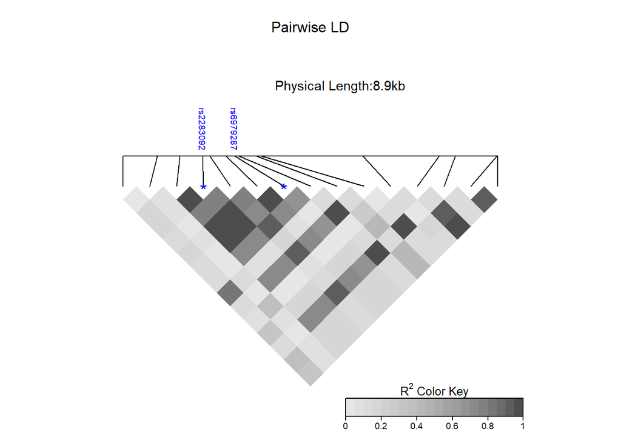

```r
 MyHeatmapSymbols <- LDTest(MyHeatmap, SNP.name = c("rs2283092", "rs6979287"))
```

```r
 #childNames(grid.get("geneMap")) # Symbols available
 childNames(MyHeatmapSymbols$LDheatmapGrob$children$geneMap)
```

```
## [1] "diagonal" "segments" "title"    "symbols"  "SNPnames"
```

```r
 # Not flipped
 MyHeatmapTest <- LDTest(CEUSNP, genetic.distances = CEUDist,
                          color = grey.colors(20), flip=FALSE)
```

```r
 MyHeatmapTestSymbols <- LDTest(MyHeatmapTest, SNP.name = c("rs2283092", "rs6979287"))
```

```r
 childNames(MyHeatmapTestSymbols$LDheatmapGrob$children$geneMap) # Symbols available
```

```
## [1] "diagonal" "segments" "title"    "symbols"  "SNPnames"
```

Bug Report 2: User reported issues with the underlying grid being entirely visible if they wanted to outline the cells in the heatmap. Request was for the cells only within the heatmap to be highlighted when using colours other than white.

Example of issue:

```r
if(!exists("LDTest", mode="function")) source("LDHeatmapTestFunctionMR.R")
if(!exists("LDheatmapMapNew.add", mode="function")) source("LDheatmapHelpers.R")
data(CEUData)
LDTest(CEUSNP, genetic.distances = CEUDist,
                          color = grey.colors(20), flip=TRUE)
```

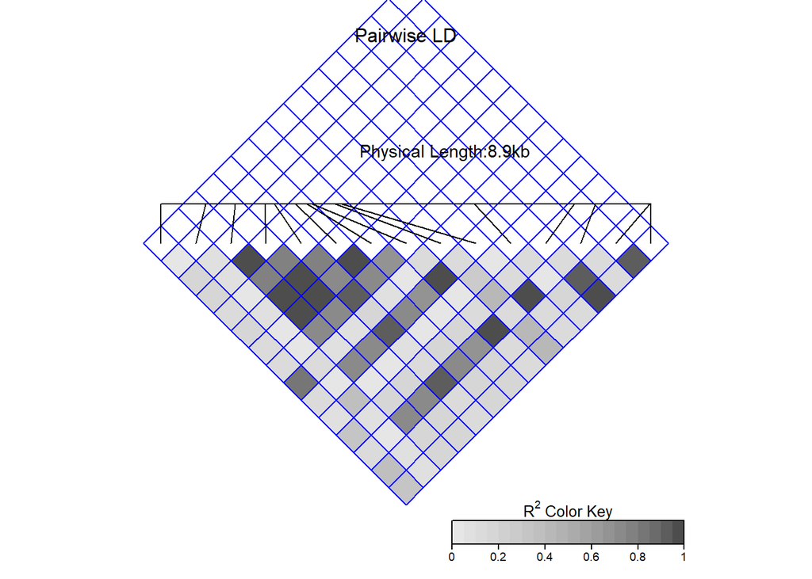

```r
grid.edit(gPath("ldheatmap", "heatMap", "heatmap"), gp = gpar(col = "blue", lwd = 1))
```

The problem demonstrated here was being caused by the grid.edit call editing all the cells in the output due to the matrix structure. Many resolution approaches could be taken to improve this situation though the path of least resistance seemed to be modifying the LDheatmap.highlight() function as it already outline groups of cells. Modifications to this function allowed it to outline the individual cells within a heatmap. Below is the modification and an exmaple of its use. Code for LDTest.highlight() has been saved in LDHeatmap.highlight.R

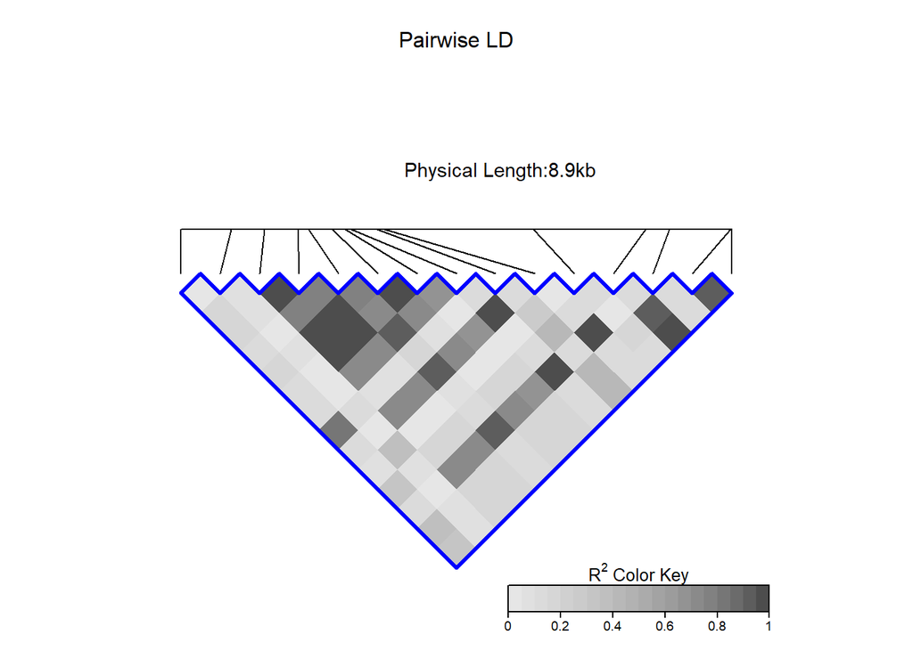

```r
if(!exists("LDTest", mode="function")) source("LDHeatmapTestFunctionMR.R")
if(!exists("LDheatmapMapNew.add", mode="function")) source("LDheatmapHelpers.R")
LDTest.highlight <- function(LDheatmap, i, j, fill="NA", col="black", lwd=1, lty=1, flipOutline=F, crissCross = F){

  requireNamespace("grid")
  # Highlights the perimeter of selected cells in the heatmap as a block
  backbone <- function(i,j,nSNP){
    x <- c(i-1,i-1,j-1)/nSNP
    y <- c(i,j,j)/nSNP
    cbind(x,y)
  }
  backboneFlip <- function(i,j,nSNP){
    x <- c(i,j,j)/nSNP
    y <- c(i-1,i-1,j-1)/nSNP
    cbind(x,y)
  }

  rectVert <- function(i, j , nSNP){
    rectangles <- data.frame()
    for( k in i:(j-1)){
      x <- c(k, k, k + 1, k + 1) / nSNP
      y <- c(k, j, k, j) / nSNP
      coords <- cbind(x, y)
      rectangles <- rbind(rectangles, coords)
    }
    return(rectangles)
  }

  rectHorizontal <- function(i, j ,nSNP){
    rectangles <- data.frame()
    for(m in i:(j-1)){
      x <- c(i-1, m , i-1, m) / nSNP
      y <- c(m+1, m+1, m+2, m+2) / nSNP
      coords <- cbind(x, y)
      rectangles <- rbind(rectangles, coords)
    }
    return(rectangles)
  }

  zigzag <- function(i,j,nSNP){
    c1 <- j-i
    nvert <- (2*c1)-1
    x <-c(j-1,rep((j-2):(j-c1),each=2))
    y <- c(rep((j-1):(j-(c1-1)),each=2),j-c1)
    cbind(x,y)/nSNP
  }
  zigzagFlip <- function(i,j,nSNP){
    c1 <- j-i
    nvert <- (2*c1)-1
    y <-c(j-1,rep((j-2):(j-c1),each=2))
    x <- c(rep((j-1):(j-(c1-1)),each=2),j-c1)
    cbind(x,y)/nSNP
  }

  nSNP <- dim(LDheatmap$LDmatrix)[1]
  if(length(i)>1 | length (j) > 1) stop("i and j must be scalar indices")
  if((i<1 | i>nSNP) |(j<1 | j>nSNP) )
    stop(paste("index out of bounds, i and j must be in (1,",nSNP,")",sep=""))
  if(i==j) stop("i cannot be equal to j")
  if(i>j){
    h<-i
    i <- j
    j <- h
  }
  pgon <- data.frame(rbind(backbone(i,j,nSNP), zigzag(i,j,nSNP)))
  if(!is.null(LDheatmap$flipVP)) pgon <- data.frame(rbind(backboneFlip(i,j,nSNP), zigzagFlip(i,j,nSNP)))
  ## Square or almost square interior Blocks
  names(pgon) <- c("x","y")
  # For the grid highlight case
  vertRectangles <- rectVert(i, j, nSNP = dim(LDheatmap$LDmatrix)[1])
  horizonRectangles <- rectHorizontal(i, j, nSNP = dim(LDheatmap$LDmatrix)[1])
  names(vertRectangles) <- c("x", "y")
  names(horizonRectangles) <- c("x", "y")
  #
  heatmap.vp <- LDheatmap$heatmapVP$name
  #If heatmap.vp is on the grid display list, i.e., it is included in the
  #returned value of current.vpTree(), a[1]=1 else a[1]=NA:
  a <- grep(paste("[", heatmap.vp, "]", sep=""), as.character(current.vpTree()), fixed=TRUE)
  if(!is.na(a[1]))   seekViewport(heatmap.vp)
  else               pushViewport(LDheatmap$heatmapVP)
  if (!is.null(LDheatmap$flipVP)) pushViewport(LDheatmap$flipVP)
  # Added section #
  if(flipOutline == T){
    tempy <- pgon$y
    tempx <- pgon$x
    pgon$y <- tempx
    pgon$x <- tempy
  }
  highlight <- polygonGrob(x=pgon$x, y=pgon$y,
                           gp=gpar(col=col, fill=fill, lwd=lwd, lty=lty), name="highlight")

 #
  if(crissCross == TRUE){

    for(i in 1:(dim(vertRectangles)[1]/4)){
      width <- vertRectangles$x[(i-1)*4 + 3] - vertRectangles$x[(i-1)*4 + 1]
      height <- vertRectangles$y[(i-1)*4 + 1] - vertRectangles$y[(i-1)*4 + 2]
      if(is.null(LDheatmap$flipVP)){
        oneRect <- rectGrob(x = vertRectangles$x[(i-1)*4+1] - width/2, y = vertRectangles$y[(i-1)*4+1] - height/2,
                            width = width,
                            height= height,
                            gp=gpar(col=col, fill=fill, lwd=lwd, lty=lty), name="rect")
      }
      else{
        # Flip is swapping of x-y coordinates, therefore reverse assignment of width and height
        width <- vertRectangles$y[(i-1)*4 + 1] - vertRectangles$y[(i-1)*4 + 2]
        height <- vertRectangles$x[(i-1)*4 + 3] - vertRectangles$x[(i-1)*4 + 1]
        oneRect <- rectGrob(x = vertRectangles$y[(i-1)*4+1] - width/2, y = vertRectangles$x[(i-1)*4+1] - height/2,
                            width = width,
                            height= height,
                            gp=gpar(col=col, fill=fill, lwd=lwd, lty=lty), name="rect")
      }

      grid.draw(oneRect)
    }
    for(j in 1:(dim(horizonRectangles)[1]/4)){
      width <- horizonRectangles$x[(j-1)*4 + 2] - horizonRectangles$x[(j-1)*4 + 1]
      height<- horizonRectangles$y[(j-1)*4 + 3] - horizonRectangles$y[(j-1)*4 + 1]
      if(is.null(LDheatmap$flipVP)){
        oneRect <- rectGrob(x = horizonRectangles$x[(j-1)*4 + 2] - width/2, y = horizonRectangles$y[(j-1)*4 + 1] - height/2,
                            width = width,
                            height = height,
                            gp=gpar(col=col, fill=fill, lwd=lwd, lty=lty), name="rect")
      }
      else{
        # Flip is swapping of x-y coordinates, therefore reverse assignment of width and height
        width <- horizonRectangles$y[(j-1)*4 + 3] - horizonRectangles$y[(j-1)*4 + 1]
        height<- horizonRectangles$x[(j-1)*4 + 2] - horizonRectangles$x[(j-1)*4 + 1]
        oneRect <- rectGrob(x = horizonRectangles$y[(j-1)*4 + 1] - width/2, y = horizonRectangles$x[(j-1)*4 + 2] - height/2,
                            width = width,
                            height = height,
                            gp=gpar(col=col, fill=fill, lwd=lwd, lty=lty), name="rect")
      }
      grid.draw(oneRect)
    }
  }
  #
  grid.draw(highlight)
  if(!is.na(a[1]))  upViewport(0)  #back to the root viewport
  else              popViewport()
  invisible(pgon)
}

grid.newpage()

data(CEUData)
MyHeatmap <- LDheatmap(CEUSNP, genetic.distances = CEUDist,
                       color = grey.colors(20), flip = TRUE)
onlyOutline <- LDTest.highlight(MyHeatmap, 1, 15, col = "blue", fill = NA, lwd =3, flipOutline = FALSE, crissCross = FALSE)
```

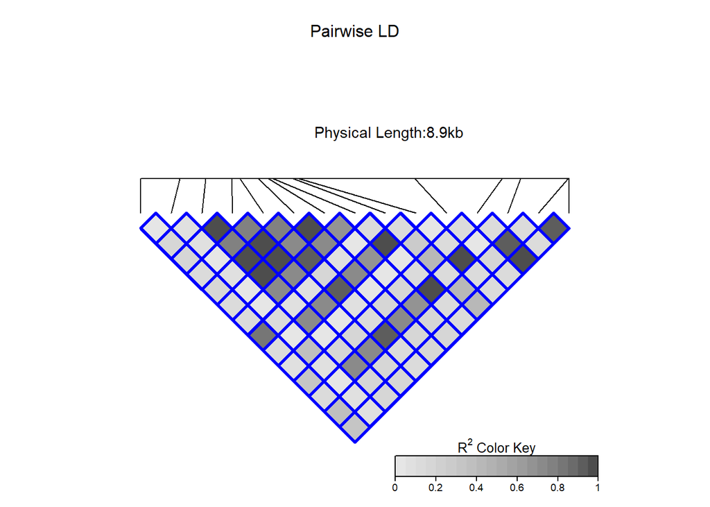

```r
MyHeatmap2 <- LDheatmap(CEUSNP, genetic.distances = CEUDist,
                       color = grey.colors(20), flip = TRUE)
allCellsOutline <- LDTest.highlight(MyHeatmap2, 1, 15, col = "blue", fill = NA, lwd =3, flipOutline = FALSE, crissCross = TRUE)
```

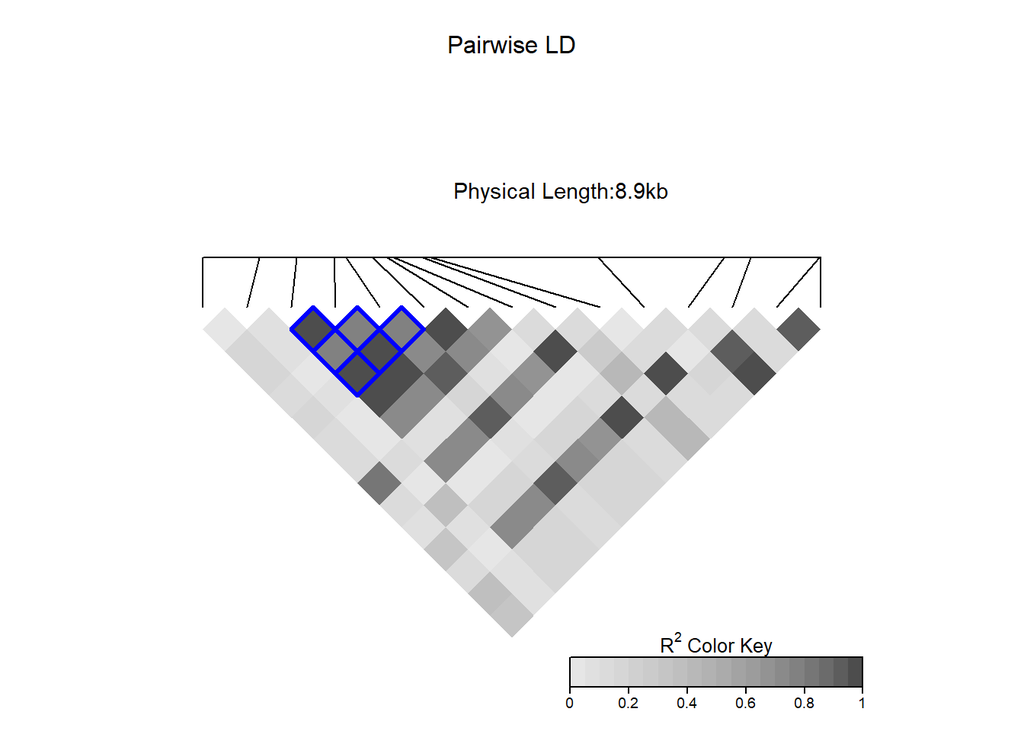

```r
# Now only some of the cells
MyHeatmap3 <- LDheatmap(CEUSNP, genetic.distances = CEUDist,
                       color = grey.colors(20), flip = TRUE)
someCellsOutline <- LDTest.highlight(MyHeatmap2, 3, 6, col = "blue", fill = NA, lwd =3, flipOutline = FALSE, crissCross = TRUE)
```

The highlighting of each cell is controlled by the crissCross parameter. A TRUE value dictates the outlining of each cell while a FALSE value dictates only the highlighting of the outer cells, the default behaviour of LDheatmap.highlight().

Bug Report 2.5: User requested the ability to control geneMap distance from heatmap. No image or reproducibility as to the idea was provided. As such, a generic function was created with the intention of providing the desired feature.

```r
if(!exists("LDTest", mode="function")) source("LDHeatmapTestFunctionMR.R")
if(!exists("LDheatmapMapNew.add", mode="function")) source("LDheatmapHelpers.R")
LDTest.moveGenemap <- function(LDheatmap, distance = "close"){
  if(is.null(LDheatmap$flipVP)){
    print("Not Flipped")
    if(distance == "close") temp <- editGrob(LDheatmap$LDheatmapGrob, gPath("geneMap"), vp = viewport(x = unit(0.52, "snpc"), y = unit(0.48, "snpc")))
    if(distance == "medium") temp <- editGrob(LDheatmap$LDheatmapGrob, gPath("geneMap"), vp = viewport(x = unit(0.56, "snpc"), y = unit(0.44, "snpc")))
    if(distance == "far") temp <- editGrob(LDheatmap$LDheatmapGrob, gPath("geneMap"), vp = viewport(x = unit(0.60, "snpc"), y = unit(0.4, "snpc")))
  }
  else{
    print("Flipped")
    if(distance == "close") temp <- editGrob(LDheatmap$LDheatmapGrob, gPath("geneMap"), vp = viewport(x = unit(0.5, "snpc"), y = unit(0.52, "snpc")))
    if(distance == "medium") temp <- editGrob(LDheatmap$LDheatmapGrob, gPath("geneMap"), vp = viewport(x = unit(0.5, "snpc"), y = unit(0.56, "snpc")))
    if(distance == "far") temp <- editGrob(LDheatmap$LDheatmapGrob, gPath("geneMap"), vp = viewport(x = unit(0.5, "snpc"), y = unit(0.6, "snpc")))
  }
  LDheatmap$LDheatmapGrob <- temp
  return(LDheatmap)
}

data(CEUData)
testMap <- LDTest(CEUSNP, genetic.distances = CEUDist,
                               color = grey.colors(20), flip = TRUE)
```

```r
movedGenemap <- LDTest.moveGenemap(testMap, distance = "medium")
```

```
## [1] "Flipped"
```

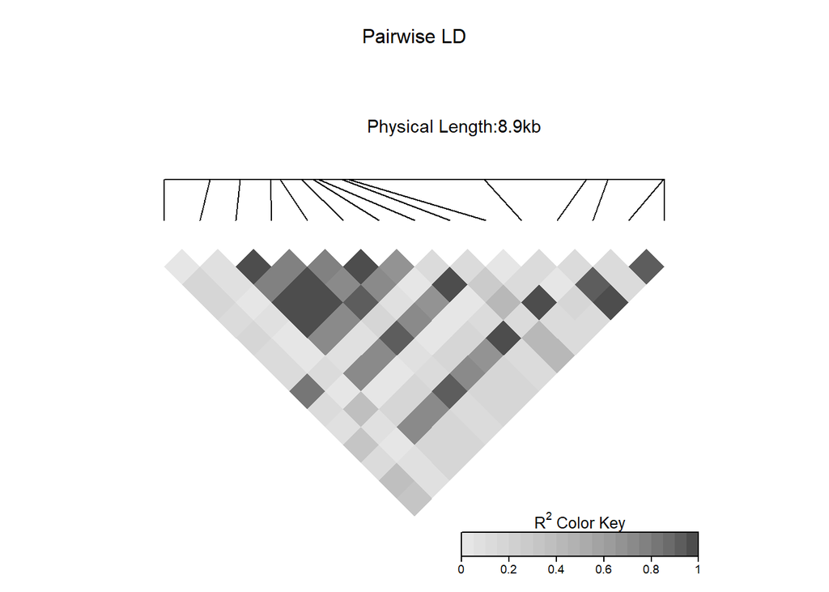

```r
grid.newpage()
grid.draw(movedGenemap$LDheatmapGrob)
```

```r
testMap2 <- LDTest(CEUSNP, genetic.distances = CEUDist,
                               color = grey.colors(20), flip = FALSE)
```

```r
movedGenemap2 <- LDTest.moveGenemap(testMap2, distance = "far")
```

```
## [1] "Not Flipped"
```

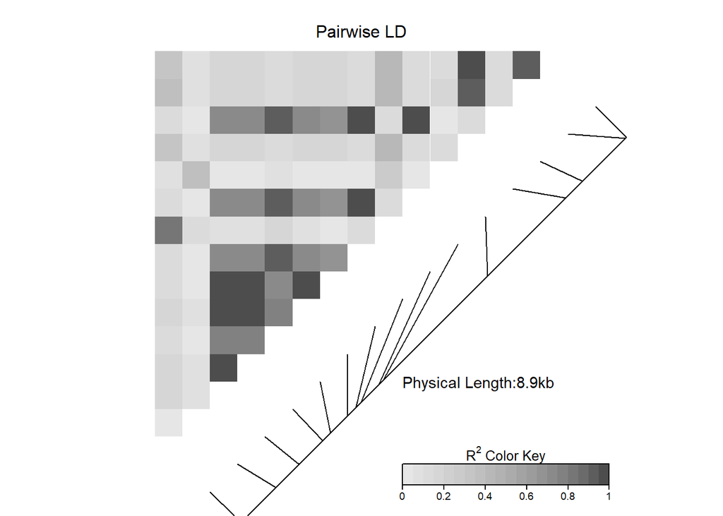

```r
grid.newpage()
grid.draw(movedGenemap2$LDheatmapGrob)
```

Movement of the genemap is controlled by the distance parameter. Currently trivial character values are used though it can be modified for exact values by changing distance to a numeric argument.

Remaining issues: Last part of this bug report/ request asked for a way to add bp positions (i.e. beginning and end positions at the segment bar). I am unsure of what these are though I can likely implement them with some advice.

Bug Report 3: When using the highlight function on a flipped graph, the output polygon is on the wrong side of the heatmap.

In testing the bug report, I was unable to duplicate the same problem the user had. Because of this, I implemented a parameter in the highlight function such that any user experiencing this problem can fix with a simple adjustment. Code changes to the highlight function are included in the earlier discussion for Bug Report 2.

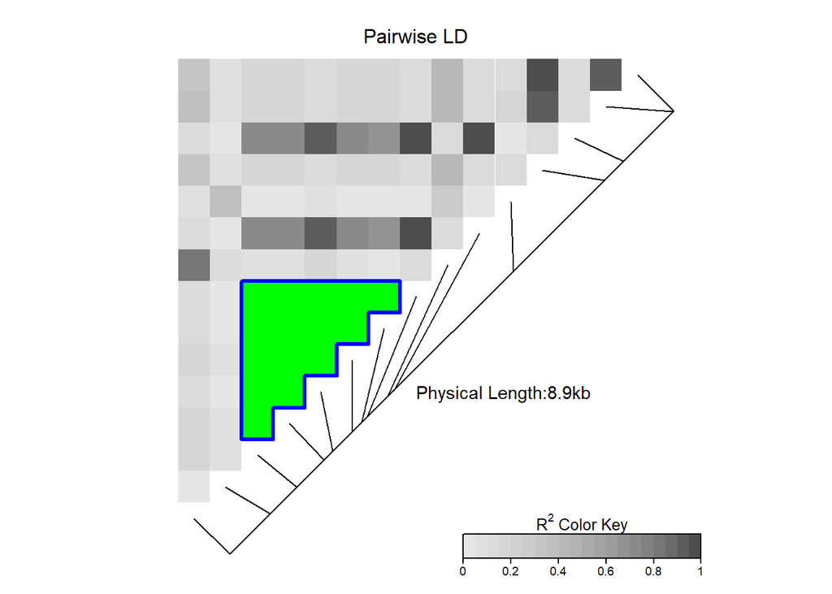

```r
# Bug report: highlight function needs to be mirrored when used with flip = TRUE #
# Sample of highlight on normal heatmap
if(!exists("LDTest", mode="function")) source("LDHeatmapTestFunctionMR.R")
if(!exists("LDheatmapMapNew.add", mode="function")) source("LDheatmapHelpers.R")
library(mvtnorm)
data(CEUData)
tt <- LDheatmap(CEUSNP, genetic.distances=CEUDist)
LDTest.highlight(tt, 3, 8, col="blue", fill="green", lwd=3)
```

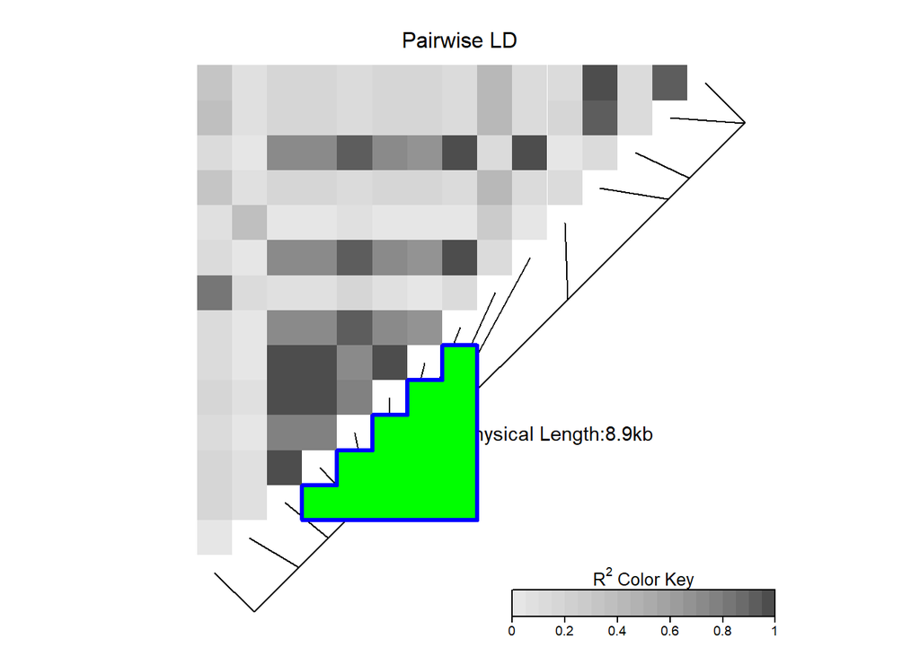

```r
tt <- LDheatmap(CEUSNP, genetic.distances=CEUDist)
LDTest.highlight(tt, 3, 8, col="blue", fill="green", lwd=3, flipOutline = TRUE)
```

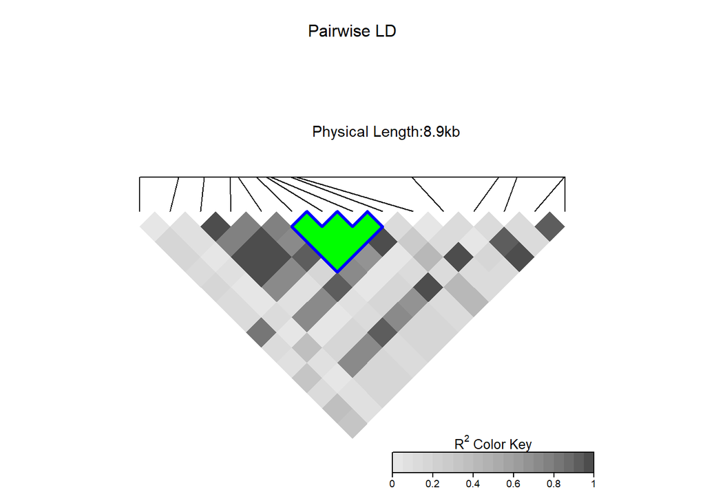

```r
# Sample of highlight on flipped heatmap
ttFlip <- LDheatmap(CEUSNP, genetic.distances = CEUDist, flip = TRUE)
LDTest.highlight(ttFlip, 6, 9, col = "blue", fill = "green", lwd = 3)
```

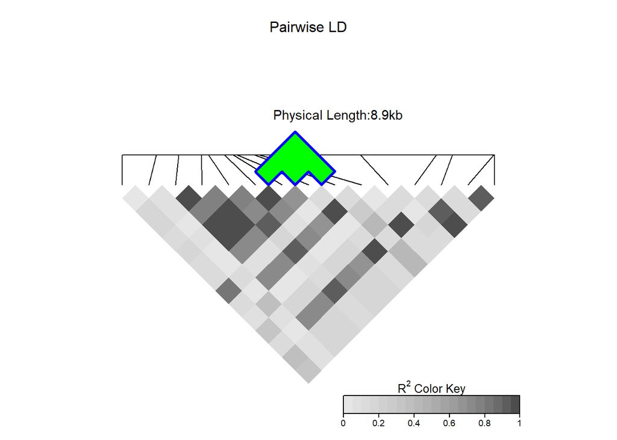

```r
# Solution: Add flipOutline parameter such that if a user encounters a flip problem they can change the flipOutline param value to reverse
ttFlip <- LDheatmap(CEUSNP, genetic.distances = CEUDist, flip = TRUE)
LDTest.highlight(ttFlip, 6, 9, col = "blue", fill = "green", lwd = 3, flipOutline = TRUE)
```

Bug Report 4: When trying to add correlation values to the individual cells, values were not being adequately mapped for flipped graphs.

Recreation of the plotting:

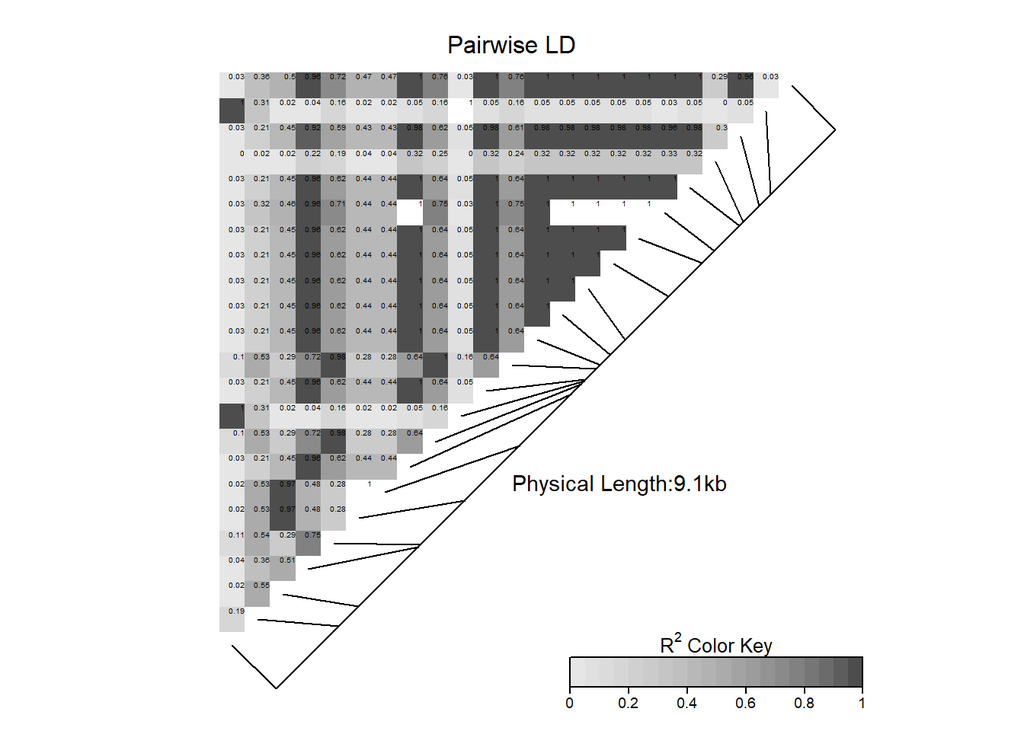

```r
data(GIMAP5.CEU)
llText <- LDheatmap(GIMAP5.CEU$snp.data,GIMAP5.CEU$snp.support$Position,flip=FALSE, text = TRUE)
```

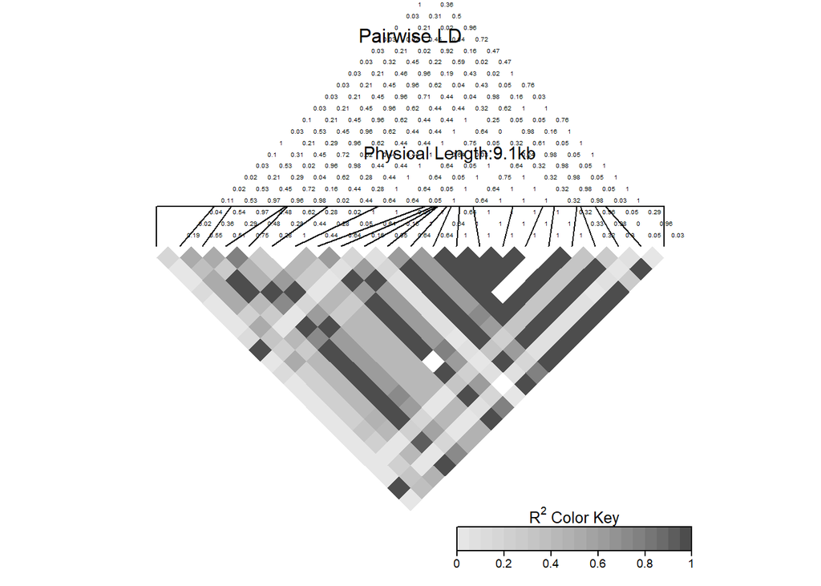

```r
llText2<- LDheatmap(GIMAP5.CEU$snp.data,GIMAP5.CEU$snp.support$Position,flip=TRUE, text = TRUE)
```

Resolving this problem involved editing the code in the LDheatmap function call. The problematic code is as follows:

```r
LDheatmapPlaceholder<-
   function (gdat, genetic.distances=NULL,
             distances="physical", LDmeasure="r", title="Pairwise LD",
             add.map=TRUE, add.key=TRUE, geneMapLocation=0.15,
             geneMapLabelX=NULL, geneMapLabelY=NULL,
             SNP.name=NULL, color=NULL,
             newpage=TRUE, name="ldheatmap", vp.name=NULL,
             pop=FALSE, flip=NULL, text=FALSE)
   {
     # # # #
      ImageText <- NULL
      if (text) ImageText<-makeImageText(dim(LDmatrix)[1],dim(LDmatrix)[2], round(imgLDmatrix, digits = 2), name="heatmaptext")
      title <- textGrob(title, 0.5, 1.05, gp=gpar(cex=1.0), name="title")
      if (flip) {
         ImageRect <- editGrob(ImageRect, vp=flipVP)
         if (text)
            ImageText <- editGrob(ImageText, vp=flipVP, rot=45, just="left")
      }
      heatMap <- gTree(children=gList(ImageRect, ImageText, title), name="heatMap")
   }
```

Generating the text for the image through a rotation of 45 degrees in the flipVP viewport causes the text to be displayed above the graph. Modification to using a rotation of 0 degrees seems to alleviate the problem. Code, as follows, is stored in the LDTest function.

```r
LDTestPlaceholder <- function(gdat, genetic.distances=NULL,
                         distances="physical", LDmeasure="r", title="Pairwise LD",
                         add.map=TRUE, add.key=TRUE, geneMapLocation=0.15,
                         geneMapLabelX=NULL, geneMapLabelY=NULL,
                         SNP.name=NULL, color=NULL,
                         newpage=TRUE, name="ldheatmap", vp.name=NULL,
                         pop=FALSE, flip=NULL, text=FALSE)
  {
    # # # #
    ImageText <- NULL
    if (text) ImageText<-makeImageText(dim(LDmatrix)[1],dim(LDmatrix)[2], round(imgLDmatrix, digits = 2), name="heatmaptext")
    title <- textGrob(title, 0.5, 1.05, gp=gpar(cex=1.0), name="title")

    if (flip) {
      ImageRect <- editGrob(ImageRect, vp=flipVP)
      if (text)
        # Added flip = TRUE parameter to better utilize makeImageText() in the flipped case
        ImageText <- makeImageText(dim(LDmatrix)[1],dim(LDmatrix)[2], round(imgLDmatrix, digits = 2), name="heatmaptext", flip = TRUE)
        ImageText <- editGrob(ImageText, vp=flipVP, rot=0, just=c("right", "top"))
    }
  }
```

The change made above involved the adding of a flip parameter to makeImageText() such that the data could be added to the graph in the appropriate order. Adjusted the call of makeImageText() in LDTest() to accomodate for the added parameter.

Demonstration of the improvement:

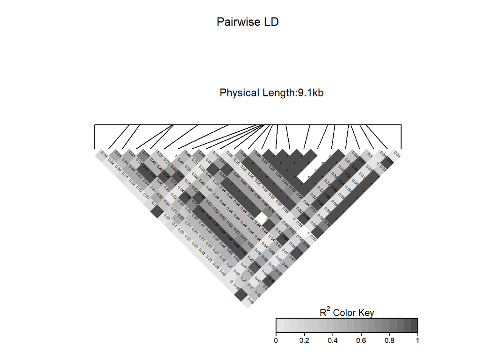

```r
if(!exists("LDTest", mode="function")) source("LDHeatmapTestFunctionMR.R")
if(!exists("LDheatmapMapNew.add", mode="function")) source("LDheatmapHelpers.R")
data(GIMAP5.CEU)
llText <- LDTest(GIMAP5.CEU$snp.data,GIMAP5.CEU$snp.support$Position,flip=TRUE, text = TRUE)
```

Need to ensure that this function is being run with the LDheatmapHelpers.R version of makeImageText(). Will further verify this test with corner case investigation.

Bug Report 5: User reported being able to successfully add 2 scatterplots above the rotated LDheatmap but was unable to incorporate 3 or more.

```r
LDheatmap.addScatterplot_test1 <- function(LDheatmap, P, height=0.2, ylab=NULL, ylim=NULL, type="points",color,pch) {
    if (dim(LDheatmap$LDmatrix)[1] != length(P)) {
    print("Length of vector not equal number of SNPs in LDheatmap")
    return()
  }

  flip <- !is.null(LDheatmap$flipVP)
  vp <- constructVP(LDheatmap$LDheatmapGrob, 0.03, flip)
  vp$height <- unit(height, "npc")
  vp$name <- "associationVP"


  if (is.null(ylim))
    ylim <- c(floor(min(P)), ceiling(max(P)))
  vp$yscale <- ylim
  vp$xscale <- c(min(LDheatmap$genetic.distances), max(LDheatmap$genetic.distances))


  xaxis <- linesGrob(x = vp$xscale, y = 0, default.units = "native",
                     name = "xaxis")
  yaxis <- linesGrob(x = min(LDheatmap$genetic.distances),
                     y = vp$yscale, default.units = "native", name = "yaxis")
  yaxisT <- yaxisGrob(name = "yaxis_ticks", gp = gpar(fontsize = 7))
  ylab <- textGrob(ylab, rot = 90, gp = gpar(fontsize = 9),
                   name = "yaxis_title", x = unit(min(LDheatmap$genetic.distances),
                                                  "native") - unit(10, "millimeters"))
  vpstack <- vp
  if (flip)
    vpstack <- vpStack(LDheatmap$flipVP, vp)
  association <- gTree(children = gList(xaxis, yaxis, yaxisT,
                                        ylab), name = "association", vp = vpstack)

  if (type == "points" || type == "both") {
    graph_points <- pointsGrob(LDheatmap$genetic.distances, P, size = unit(2, "millimeters"), name = "points",pch=16, gp=gpar(col="red"))
    association <- addGrob(association, graph_points)
  }
  if (type == "lines" || type == "both") {
    graph_lines <- linesGrob(LDheatmap$genetic.distances,
                             P, default.units = "native", name = "lines")
    association <- addGrob(association, graph_lines)
  }
  LDheatmap$LDheatmapGrob <- addGrob(LDheatmap$LDheatmapGrob,
                                     association)
  LDheatmap$LDheatmapGrob <- moveTitles(LDheatmap$LDheatmapGrob,
                                        vp)
  return(LDheatmap)
}
environment(LDheatmap.addScatterplot_test1) <- asNamespace('LDheatmap')

LDheatmap.addScatterplot_test2 <- function(LDheatmap, P, height=0.2, ylab=NULL, ylim=NULL, type="points",color,pch) {
  if (dim(LDheatmap$LDmatrix)[1] != length(P)) {
    print("Length of vector not equal number of SNPs in LDheatmap")
    return()
  }
  flip <- !is.null(LDheatmap$flipVP)
  vp <- constructVP(LDheatmap$LDheatmapGrob, 0.03, flip)
  vp$height <- unit(height, "npc")
  vp$name <- "associationVP"
  if (is.null(ylim))
    ylim <- c(floor(min(P)), ceiling(max(P)))
  vp$yscale <- ylim
  vp$xscale <- c(min(LDheatmap$genetic.distances), max(LDheatmap$genetic.distances))
  xaxis <- linesGrob(x = vp$xscale, y = 0, default.units = "native",
                     name = "xaxis")
  yaxis <- linesGrob(x = min(LDheatmap$genetic.distances),
                     y = vp$yscale, default.units = "native", name = "yaxis")
  yaxisT <- yaxisGrob(name = "yaxis_ticks", gp = gpar(fontsize = 7))
  ylab <- textGrob(ylab, rot = 90, gp = gpar(fontsize = 9),
                   name = "yaxis_title", x = unit(min(LDheatmap$genetic.distances),
                                                  "native") - unit(10, "millimeters"))
  vpstack <- vp
  if (flip)
    vpstack <- vpStack(LDheatmap$flipVP, vp)
  association2 <- gTree(children = gList(xaxis, yaxis, yaxisT,
                                         ylab), name = "association2", vp = vpstack)
  if (type == "points" || type == "both") {
    graph_points <- pointsGrob(LDheatmap$genetic.distances, P, size = unit(2, "millimeters"), name = "points",pch=16, gp=gpar(col="purple"))
    association2 <- addGrob(association2, graph_points)
  }
  if (type == "lines" || type == "both") {
    graph_lines <- linesGrob(LDheatmap$genetic.distances,
                             P, default.units = "native", name = "lines")
    association2 <- addGrob(association2, graph_lines)
  }
  LDheatmap$LDheatmapGrob <- addGrob(LDheatmap$LDheatmapGrob,
                                     association2)
  LDheatmap$LDheatmapGrob <- moveTitles(LDheatmap$LDheatmapGrob,
                                        vp)
  return(LDheatmap)

}
environment(LDheatmap.addScatterplot_test2) <- asNamespace('LDheatmap')

LDheatmap.addScatterplot_test3 <- function(LDheatmap, P, height=0.2, ylab=NULL, ylim=NULL, type="points",color,pch) {

   if (dim(LDheatmap$LDmatrix)[1] != length(P)) {
    print("Length of vector not equal number of SNPs in LDheatmap")
    return()
  }
  flip <- !is.null(LDheatmap$flipVP)
  vp <- constructVP(LDheatmap$LDheatmapGrob, 0.23, flip)
  vp$height <- unit(height, "npc")
  vp$name <- "associationVP"
  if (is.null(ylim))
    ylim <- c(floor(min(P)), ceiling(max(P)))
  vp$yscale <- ylim
  vp$xscale <- c(min(LDheatmap$genetic.distances), max(LDheatmap$genetic.distances))
  xaxis <- linesGrob(x = vp$xscale, y = 0, default.units = "native",
                     name = "xaxis")
  yaxis <- linesGrob(x = min(LDheatmap$genetic.distances),
                     y = vp$yscale, default.units = "native", name = "yaxis")
  yaxisT <- yaxisGrob(name = "yaxis_ticks", gp = gpar(fontsize = 7))
  ylab <- textGrob(ylab, rot = 90, gp = gpar(fontsize = 9),
                   name = "yaxis_title", x = unit(min(LDheatmap$genetic.distances),
                                                  "native") - unit(10, "millimeters"))
  vpstack <- vp
  if (flip)
    vpstack <- vpStack(LDheatmap$flipVP, vp)
  association3 <- gTree(children = gList(xaxis, yaxis, yaxisT,
                                         ylab), name = "association3", vp = vpstack)
  if (type == "points" || type == "both") {
    graph_points <- pointsGrob(LDheatmap$genetic.distances, P, size = unit(2, "millimeters"), name = "points",pch=16, gp=gpar(col="green4"))
    association3 <- addGrob(association3, graph_points)
  }
  if (type == "lines" || type == "both") {
    graph_lines <- linesGrob(LDheatmap$genetic.distances,
                             P, default.units = "native", name = "lines")
    association3 <- addGrob(association3, graph_lines)
  }
  LDheatmap$LDheatmapGrob <- addGrob(LDheatmap$LDheatmapGrob,
                                     association3)
  LDheatmap$LDheatmapGrob <- moveTitles(LDheatmap$LDheatmapGrob,
                                        vp)
  return(LDheatmap)
}
environment(LDheatmap.addScatterplot_test3) <- asNamespace('LDheatmap')


LDheatmap.addScatterplot_test4 <- function(LDheatmap, P, height=0.2, ylab=NULL, ylim=NULL, type="points",color,pch) {

   if (dim(LDheatmap$LDmatrix)[1] != length(P)) {
    print("Length of vector not equal number of SNPs in LDheatmap")
    return()
  }
  flip <- !is.null(LDheatmap$flipVP)
  vp <- constructVP(LDheatmap$LDheatmapGrob, 0.43, flip)
  vp$height <- unit(height, "npc")
  vp$name <- "associationVP"
  if (is.null(ylim))
    ylim <- c(floor(min(P)), ceiling(max(P)))
  vp$yscale <- ylim
  vp$xscale <- c(min(LDheatmap$genetic.distances), max(LDheatmap$genetic.distances))
  xaxis <- linesGrob(x = vp$xscale, y = 0, default.units = "native",
                     name = "xaxis")
  yaxis <- linesGrob(x = min(LDheatmap$genetic.distances),
                     y = vp$yscale, default.units = "native", name = "yaxis")
  yaxisT <- yaxisGrob(name = "yaxis_ticks", gp = gpar(fontsize = 7))
  ylab <- textGrob(ylab, rot = 90, gp = gpar(fontsize = 9),
                   name = "yaxis_title", x = unit(min(LDheatmap$genetic.distances),
                                                  "native") - unit(10, "millimeters"))
  vpstack <- vp
  if (flip)
    vpstack <- vpStack(LDheatmap$flipVP, vp)
  association4 <- gTree(children = gList(xaxis, yaxis, yaxisT,
                                         ylab), name = "association4", vp = vpstack)
  if (type == "points" || type == "both") {
    graph_points <- pointsGrob(LDheatmap$genetic.distances, P, size = unit(2, "millimeters"), name = "points",pch=16, gp=gpar(col="black"))
    association4 <- addGrob(association4, graph_points)
  }
  if (type == "lines" || type == "both") {
    graph_lines <- linesGrob(LDheatmap$genetic.distances,
                             P, default.units = "native", name = "lines")
    association4 <- addGrob(association4, graph_lines)
  }
  LDheatmap$LDheatmapGrob <- addGrob(LDheatmap$LDheatmapGrob,
                                     association4)
  LDheatmap$LDheatmapGrob <- moveTitles(LDheatmap$LDheatmapGrob,
                                        vp)
  return(LDheatmap)
}
environment(LDheatmap.addScatterplot_test4) <- asNamespace('LDheatmap')
```

```r
constructVP <- function(LDheatmapGrob, location=0, flip) {

  x0 <- convertX(getGrob(LDheatmapGrob, "diagonal")[[1]][1], "npc", valueOnly=TRUE)
  x1 <- convertX(getGrob(LDheatmapGrob, "diagonal")[[1]][2], "npc", valueOnly=TRUE)
  y0 <- convertX(getGrob(LDheatmapGrob, "diagonal")[[2]][1], "npc", valueOnly=TRUE)
  y1 <- convertX(getGrob(LDheatmapGrob, "diagonal")[[2]][2], "npc", valueOnly=TRUE)
  map_len = sqrt((x1-x0)^2 + (y1-y0)^2)     # genetic map length in npc units

  g_height <- g_x0 <- g_y0 <- 0
  if(!is.null(getGrob(LDheatmapGrob, "transcripts"))) { # if gene track has been plotted
    transcriptsVP <- getGrob(LDheatmapGrob, "transcripts")$vp
    if (flip) transcriptsVP <- transcriptsVP[[2]]
    g_x0 <- convertX(transcriptsVP$x, "npc", valueOnly=TRUE)
    g_y0 <- convertX(transcriptsVP$y, "npc", valueOnly=TRUE)
    g_height <- convertX(transcriptsVP$height, "npc", valueOnly=TRUE)
  }

  r_height <- r_x0 <- r_y0 <- 0
  if(!is.null(getGrob(LDheatmapGrob, "recombRate"))) {  # if recombRate track has been plotted
    recombRateVP <- getGrob(LDheatmapGrob, "recombRate")$vp
    if (flip) recombRateVP <- recombRateVP[[2]]
    r_x0 <- convertX(recombRateVP$x, "npc", valueOnly=TRUE)
    r_y0 <- convertX(recombRateVP$y, "npc", valueOnly=TRUE)
    r_height <- convertX(recombRateVP$height, "npc", valueOnly=TRUE)
  }

  m_height <- m_x0 <- m_y0 <- 0
  if(!is.null(getGrob(LDheatmapGrob, "association"))) { # if association scatterplot has been plotted
    assocVP <- getGrob(LDheatmapGrob, "association")$vp
    if (flip) assocVP <- assocVP[[2]]
    m_x0 <- convertX(assocVP$x, "npc", valueOnly=TRUE)
    m_y0 <- convertX(assocVP$y, "npc", valueOnly=TRUE)
    m_height <- convertX(assocVP$height, "npc", valueOnly=TRUE)
  }

  # Set the viewport
  if (!flip) {              # flip = FALSE
     angle <- 45
     genome_vp_just <- c("left", "top")
  }else {               # flip = TRUE
     angle <- 45
     genome_vp_just <- c("left", "bottom")
  }
  vp <- viewport(angle=angle, just=genome_vp_just, width=map_len,
    x=min(x0,  g_x0 - g_height*0.8, r_x0 - r_height*0.8, m_x0 - m_height*0.8) - location,
    y=max(y0,  g_y0 + g_height*0.8, r_y0 + r_height*0.8, m_y0 + m_height*0.8) + location)
  return (vp)
}

moveTitles <- function(LDheatmapGrob, vp) {

  genemap_title_y <- convertX(getGrob(LDheatmapGrob,"geneMap::title")$y,
                        "npc", valueOnly=TRUE)
  genemap_title_x <- convertX(getGrob(LDheatmapGrob,"geneMap::title")$x,
                        "npc", valueOnly=TRUE)
  flipVP <- getGrob(LDheatmapGrob,"geneMap::diagonal")$vp

  if (is.null(flipVP)) {                    # flip = FALSE
     if (genemap_title_y == 0.3 & genemap_title_x == 0.5)   # user used default setting
    LDheatmapGrob <- editGrob(LDheatmapGrob,"geneMap::title", y=unit(0.1, "npc"),
            x=unit(1.1, "npc"), just="right")
     grid.newpage()
     grid.draw(LDheatmapGrob)
     return(LDheatmapGrob)
  }

  # Get top of viewport coordinates in inches on the device
  pushViewport(LDheatmapGrob$vp)
  pushViewport(flipVP)
  vp_trans <- current.transform()
  temp <- c(
convertX(vp$x, "inches", valueOnly=TRUE) - convertX(vp$height, "inches",valueOnly=TRUE)/sqrt(2),
convertX(vp$y, "inches", valueOnly=TRUE) + convertX(vp$height, "inches", valueOnly=TRUE)/sqrt(2), 1)
  upViewport()
  tr <- temp %*% vp_trans  # (x, y, 1) on device

  # Get genemap title coordinates in inches on the device
  vp_trans1 <- current.transform()
  genemap_title_y_inch <- convertY(getGrob(LDheatmapGrob,"geneMap::title")$y, "inches", valueOnly=TRUE)
  temp1 <- c(0, genemap_title_y_inch, 1)
  tr1 <- temp1 %*% vp_trans1


  # Move gene map title # if necessary
  new_genemap_title_y_inch <- t(solve(t(vp_trans1), t(tr)))[1,2]
  new_genemap_title_y_npc <- convertY(unit(new_genemap_title_y_inch, "inches"), "npc", valueOnly=TRUE) + 0.05

  LDheatmapGrob <- editGrob(LDheatmapGrob, "geneMap::title",
    y = unit(new_genemap_title_y_npc, "npc"), just=c("left","bottom"))


  # Move heat map title if necessary
  heatmap_title_y <- convertY(getGrob(LDheatmapGrob,"heatMap::title")$y, "npc", valueOnly=TRUE)
  genemap_title_height <- convertHeight(grobHeight(getGrob(LDheatmapGrob,"geneMap::title")),
        "npc", valueOnly=TRUE)

  if (heatmap_title_y < new_genemap_title_y_npc + genemap_title_height*3) {
     new_heatmap_title_y <- new_genemap_title_y_npc + genemap_title_height*3
     LDheatmapGrob <- editGrob(LDheatmapGrob, "heatMap::title",
        y = unit(new_heatmap_title_y, "npc"))
  }

  drawLDheatmapGrob(LDheatmapGrob)
  return(LDheatmapGrob)
}

drawLDheatmapGrob <- function(LDheatmapGrob) {
  heatmap_title_y <- convertY(getGrob(LDheatmapGrob,"heatMap::title")$y, "npc", valueOnly=TRUE)
  vp = viewport(height=1/heatmap_title_y, width=1, y=0.05, just="bottom",
        gp=gpar(cex=1/heatmap_title_y), name="container")
  grid.newpage()
  pushViewport(vp)
  grid.draw(LDheatmapGrob)
  popViewport()
}
```

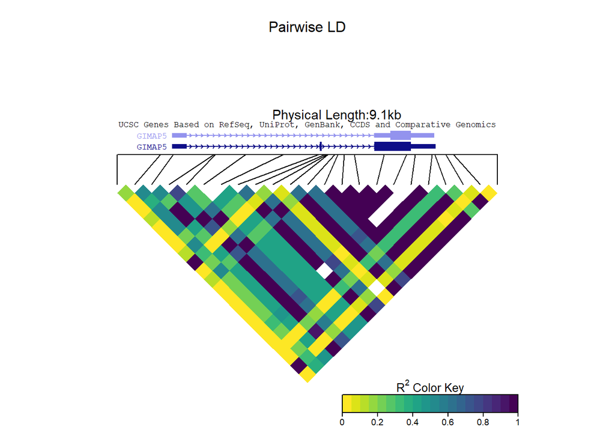

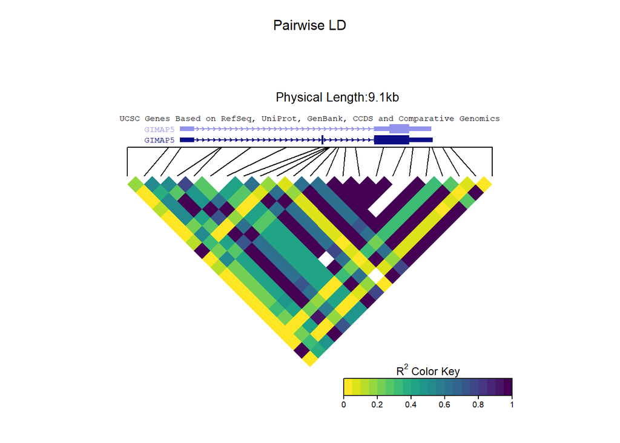

```r
data(GIMAP5.CEU)

ll <- LDheatmap(GIMAP5.CEU$snp.data,GIMAP5.CEU$snp.support$Position,flip=TRUE,color = viridis(20))
llGenes <- LDheatmap.addGenes(ll, chr="chr7", genome="hg18")
```

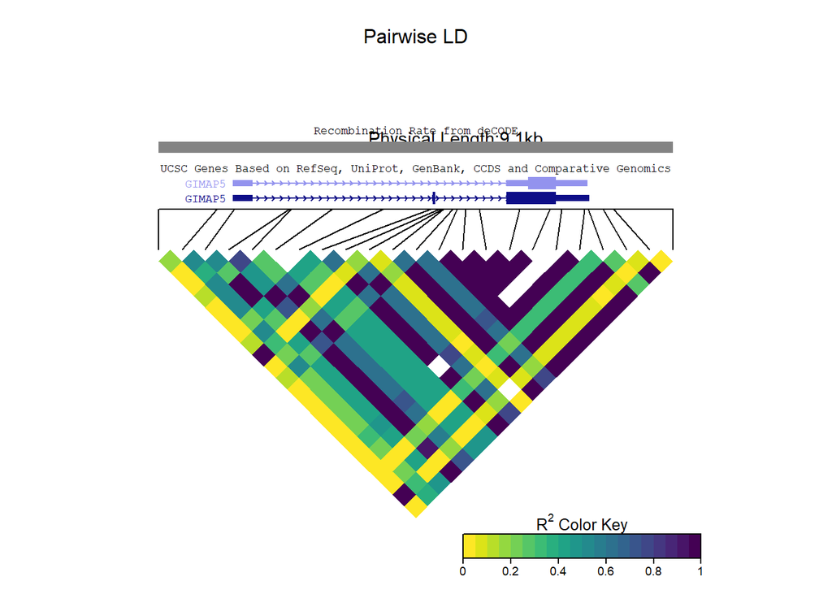

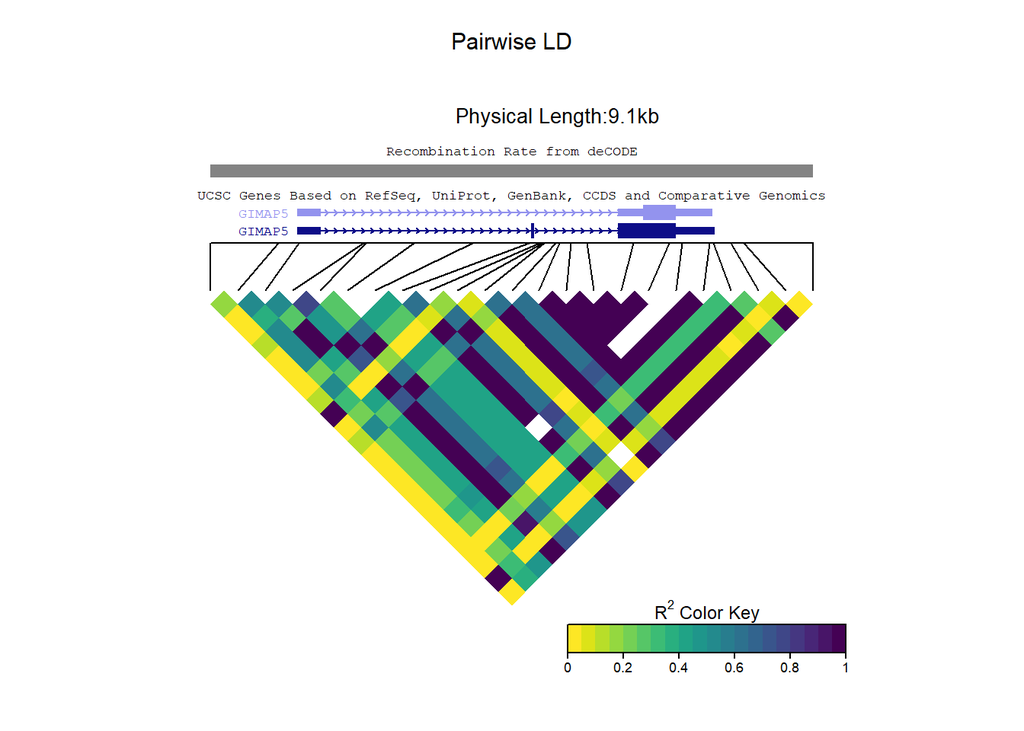

```r
 grid.newpage()
grid.draw(llGenes$LDheatmapGrob)
llGenesRecomb <- LDheatmap.addRecombRate(llGenes, chr="chr7", genome="hg18")
```

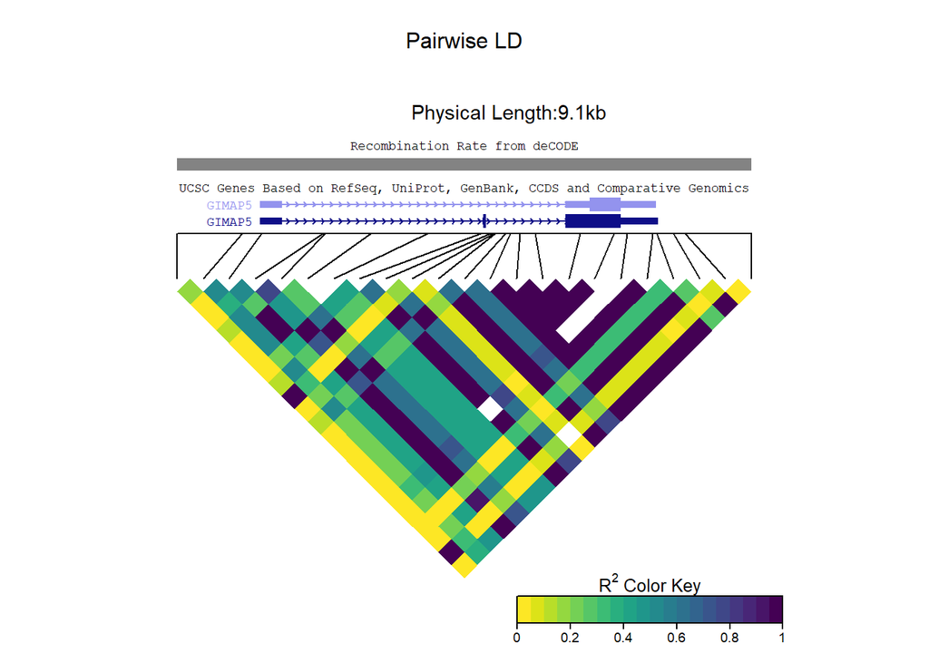

```r
grid.newpage()
grid.draw(llGenesRecomb$LDheatmapGrob)

set.seed(1)
atests<-runif(nrow(GIMAP5.CEU$snp.support))
names(atests)<-rownames(GIMAP5.CEU$snp.support)
atests["rs6598"]<-1e-5



llGenesRecombScatter<-LDheatmap.addScatterplot_test1(llGenes,-log10(atests), ylab="GWAS\n-log10(p-values)")
```

[figure not shown]

```r
llGenesRecombScatter2<-LDheatmap.addScatterplot_test2(llGenesRecombScatter,-log10(atests), ylab="eQTL \n-log10(p-values)")
```

[figure not shown]

```r
#pdf('tmp.pdf',width = 10,height = 8)

llGenesRecombScatter3<-LDheatmap.addScatterplot_test3(llGenesRecombScatter2,-log10(atests), ylab="CLPP")
```

[figure not shown]

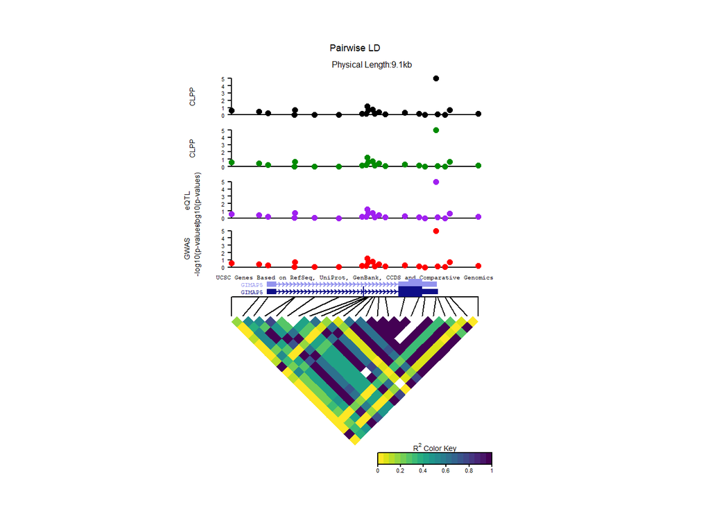

```r
llGenesRecombScatter4<-LDheatmap.addScatterplot_test4(llGenesRecombScatter3,-log10(atests), ylab="CLPP")
```